# Statistical Rethinking - chapter 2 solutions

# 2E1

*Which of the expressions below correspond to the statement: **the probability of rain on monday**?*

- *Pr(rain)*
- *Pr(rain | Monday)*
- *Pr(Monday | rain)*
- *Pr(rain, Monday) / Pr(Monday)*

Pr(rain | Monday)

# 2E2

*Which of the following statements corresponds to the expression: **Pr(Monday | rain)**?*

- *The probability of rain on Monday*
- *The probability of rain, given that it is Monday*
- *The probability that it is Monday, given that it is raining*
- *The probability that it is Monday and it is raining*

The probability that it is Monday, given that it is raining

# 2E3

*Which of the expressions below correspond to the statement: **the probability that it is Monday, given that it is raining**?*

- *Pr(Monday | rain)*
- *Pr(rain | Monday)*
- *Pr(rain | Monday) Pr(Monday)*
- *Pr(rain | Monday) Pr(Monday) / Pr(rain)*
- *Pr(Monday | rain) Pr(rain) / Pr(Monday)*

Pr(Monday | rain)

# 2M1

*Recall the globe tossing model from the chapter. Compute and plot the grid approximate posterior distribution for each of the following sets of observations. In each case, assume a uniform prior for $p$:*

1. *WWW*
2. *WWWL*
3. *LWWLWWW*

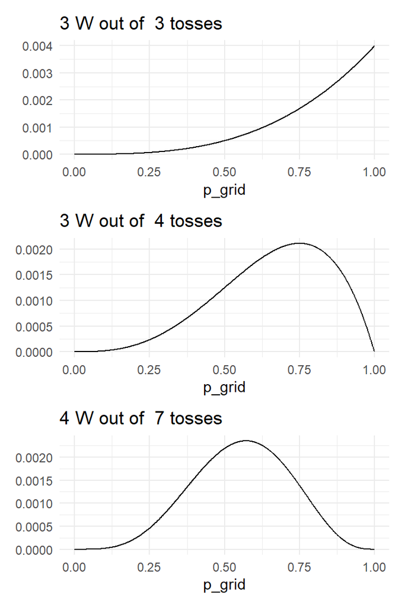

```r
library(ggplot2)
library(patchwork)

n_w = c(3, 3, 4) # Water
n_t = c(3, 4, 7) # Tosses

p_grid = seq(0, 1, length.out = 1000)

plots = list(3)
for (i in 1:3){
  lhood = dbinom(n_w[i], n_t[[i]], p_grid)
  prior = rep(1, length(p_grid))
  posterior = lhood * prior
  posterior = posterior / sum(posterior)

  plot_df = data.frame(p_grid = p_grid, posterior = posterior)
  plots[[i]] = ggplot(plot_df, aes(p_grid, posterior)) +
    geom_line() +
    labs(title = paste(n_w[[i]], 'W out of ', n_t[[i]], 'tosses'),
         y = NULL) +
    theme_minimal()

}

plots[[1]]  /
  plots[[2]] /
  plots[[3]]
```

# 2M2

*Same as above, but now use this prior:*

$$p(W) = \begin{cases}
0 & W < 0.5 \\
1 & W \geq 0.5
\end{cases}$$

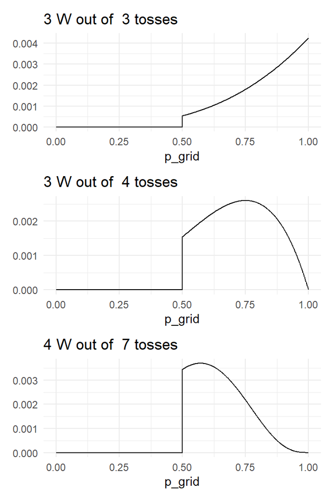

```r
n_w = c(3, 3, 4) # Water
n_t = c(3, 4, 7) # Tosses

p_grid = seq(0, 1, length.out = 1000)

plots = list(3)
for (i in 1:3){
  lhood = dbinom(n_w[i], n_t[[i]], p_grid)
  prior = ifelse(p_grid >= 0.5, 1, 0)
  posterior = lhood * prior
  posterior = posterior / sum(posterior)

  plot_df = data.frame(p_grid = p_grid, posterior = posterior)
  plots[[i]] = ggplot(plot_df, aes(p_grid, posterior)) +
    geom_line() +
    labs(title = paste(n_w[[i]], 'W out of ', n_t[[i]], 'tosses'),
         y = NULL) +
    theme_minimal()

}

plots[[1]]  /
  plots[[2]] /
  plots[[3]]
```

# 2M3

*Suppose there are two globes, one for Earth & one for Mars. The Earth globe is 70% covered in water. The Mars globe is 100% land. Further suppose that one of these globes - you don’t know which - was tossed in the air and produced a ‘land’ observation. Assuming that each globe was equally likely to be tossed, show that the posterior probability that the globe was Earth, conditional on seeing ‘land’, is 0.23*

```r
lhood = c('earth' = 0.3, 'mars' = 1) # Probability of observing land
prior = c('earth' = 1, 'mars' = 1) # Each globe equally likely to be tossed
posterior = lhood * prior
posterior = posterior / sum(posterior)

posterior['earth']
```

```
##     earth
## 0.2307692
```

# 2M4

*Suppose you have a deck with only 3 cards, Each card has two sides, and each side is either black or white. One card has two black sides. The second card has one black and one white side. The third card has two white sides. Now suppose all three cards are placed in a bag and shuffled. Someone reaches into the bag and pulls out a card and places it flat on a table. A black side is shown facing up, but you don’t know the colour of the side facing down. Show that the probability that the other side is also black is 2/3.*

This is asking for P(Face Down = B | Face Up = B). The only way that can happen is if the card is black on both sides - so we’re interested in P(draw B/B card). There’s nothing saying that we’re more likely to draw any specific card, so a flat prior is our best choice. We can enumerate all the possible ways to see the data we saw:

| Card drawn | Number of ways of getting a black face up side | Number of ways of drawing card | Total number of ways | Probability |
| --- | --- | --- | --- | --- |
| B/B | 2 | 1 | 2 | 2/3 |
| B/W | 1 | 1 | 1 | 1/3 |
| W/W | 0 | 1 | 0 | 0 |

So P(B/B) = 2/3. We can also do it computationally:

```r
lhood = c('B/B' = 2, 'B/W' = 1, 'W/W' = 0) # How many ways are there to the black side face up?
prior = c('B/B' = 1, 'B/W' = 1, 'W/W' = 1) # How likely are we to draw each card?
posterior = lhood * prior
posterior = posterior / sum(posterior)
posterior['B/B']
```

```
##       B/B
## 0.6666667
```

# 2M5

*Now suppose there are four cards - B/B, B/W, W/W, and B/B. Again suppose a card is drawn from the bag and a black side appears face up. Again calculate the probability that the other side is black.*

We’re still interested in P(B/B). The table this time is

| Card drawn | Number of ways of getting a black face up side | Number of ways of drawing card | Total number of ways | Probability |
| --- | --- | --- | --- | --- |
| B/B | 2 | 2 | 4 | 4/5 |
| B/W | 1 | 1 | 1 | 1/5 |
| W/W | 0 | 1 | 0 | 0 |

Here’s the computation:

```r
lhood = c('B/B' = 2, 'B/W' = 1, 'W/W' = 0) # How many ways are there to the black side face up?
prior = c('B/B' = 2, 'B/W' = 1, 'W/W' = 1) # How likely are we to draw each card?
posterior = lhood * prior
posterior = posterior / sum(posterior)
posterior['B/B']
```

```
## B/B
## 0.8
```

# 2M6

*Imagine that black ink is heavy, and so cards with black sides are heavier than cards with white sides. As a result, it’s less likely that a card with black sides is pulled from the bag. So again assume there are three cards: B/B, B/W, and W/W. After experimenting a number of times, you conclude that for every way to ull the B/B card from the bag, there are 2 ways to pull the B/W card and 3 ways to pull the W/W card. Again suppose that a card is pulled and a black side appears face up. Show that the probability the other side is black is now 0.5*

This problem is talking about changing the prior. Table:

| Card drawn | Number of ways of getting a black face up side | Number of ways of drawing card | Total number of ways | Probability |
| --- | --- | --- | --- | --- |
| B/B | 2 | 1 | 2 | 1/2 |
| B/W | 1 | 2 | 2 | 1/2 |
| W/W | 0 | 3 | 0 | 0 |

Code:

```r
lhood = c('B/B' = 2, 'B/W' = 1, 'W/W' = 0) # How many ways are there to the black side face up?
prior = c('B/B' = 1, 'B/W' = 2, 'W/W' = 3) # How likely are we to draw each card?
posterior = lhood * prior
posterior = posterior / sum(posterior)
posterior['B/B']
```

```
## B/B
## 0.5
```

# 2M7

*Assume again the original card problem, with a single card showing a black side face up. Before looking at the other side, we draw another card from the bag and lay it face up on the table. The face that is shown on the new card is white. Show that the probability that the first card, the one showing a black side, has black on its other side is now 0.75*

Bit trickier to keep track of the numbers for the second column - now we need to count the number of ways to get a black on the first card, then a white on the second. If we pick B/B as the first card, then there are 2 ways to get a black on the first card. Now we randomly pick a card out of the 2 remaining (B/W and W/W). If we pick B/W there is 1 way to get a white side, and if we pick W/W there are 2 ways. This gives a total of 3 (1 + 2) possible ways of getting a white. Times these all together to get the total number of ways of observing the data, assuming we first draw B/B. Then repeat that for the other two cards to get the table. Here it is:

| Card drawn | Number of ways of getting 1 black, 1 white | Number of ways of drawing card | Total number of ways | Probability |
| --- | --- | --- | --- | --- |
| B/B | 6 | 1 | 6 | 3/4 |
| B/W | 2 | 1 | 2 | 1/4 |
| W/W | 0 | 1 | 0 | 0 |

And the code:

```r
lhood = c('B/B' = 6, 'B/W' = 2, 'W/W' = 0) # How many ways are there to the black side face up?
prior = c('B/B' = 1, 'B/W' = 1, 'W/W' = 1) # How likely are we to draw each card?
posterior = lhood * prior
posterior = posterior / sum(posterior)
posterior['B/B']
```

```
##  B/B
## 0.75
```

# 2H1

*Suppose there are two species of panda bear. Both are equally common in the wild and live in the same places. They look exactly alike and eat the same food, and there is yet no genetic assay capable of telling them apart. They differ however in their family sizes. Species A gives birth to twins 10% of the time, otherwise birthing a single infant. Species B births twins 20% of the time, otherwise birthing singleton infants. Assume these numbers are known with certainty.*

*Now suppose that you are managing a captive panda breeding program. You have a new female panda of unknown species, and she has just given birth to twins. What is the probability that her next birth will also be twins?*

So there are two species, A & B. A gives birth to twins 10% of the time, and B gives birth to twins 20% of the time. We’re interested in $P(birth_2 = twins | birth_1 = twins)$. Using the chain rule, we can write this as:

$$P(b_2 = t | b_1 = t) = P(b_2 = t | b_1 = t, s = A)P(s = A | b_1 = t) + P(b_2 = t | b_1 = t, s = B)P(s = B | b_1 = t)$$
There’s no reason to think that the first birth would influence the second birth (except through the species of panda), so this becomes

$$P(b_2 = t | b_1 = t) = P(b_2 = t | s = A)P(s = A | b_1 = t) + P(b_2 = t | s = B)P(s = B | b_1 = t)$$

And this is something we can actually compute. The text tells us that the probability of twins is 0.1 & 0.2 for species A & B respectively. We need to choose priors for species but, since we don’t know anything, we’re going to go with flat ones:

```r
p_twin = c('A' = 0.1, 'B' = 0.2) # Probability of twins - likelihood
p_species = c('A' = 1, 'B' = 1) # Prior on species

posterior = p_twin * p_species
posterior = posterior / sum(posterior)

# Posterior is the P(s = A | b_1 = t) terms. Now multiply by the likelihood of twins
# and sum to get the answer
sum(p_twin * posterior)
```

```
## [1] 0.1666667
```

# 2H2

*Recall all the facts from the problem above. Now compute the probability that the panda we have is from species A, assuming we have observed only the first birth and that it was twins*

We’ve already calculated this in the previous question:

```r
posterior['A']
```

```
##         A
## 0.3333333
```

# 2H3

*Continuing on from the previous problem, suppose the same panda mother has a second birth and that it is not twins, but a singleton infant. Compute the posterior probability that the panda is species A*

```r
lhood = c('A' = 0.1 * 0.9, 'B' = 0.2 * 0.8)
p_species = c('A' = 1, 'B' = 1)

posterior = lhood * p_species
posterior = posterior / sum(posterior)

posterior['A']
```

```
##    A
## 0.36
```

# 2H4

*A common boast of Bayesian statisticians is that Bayesian inference makes it easy to use all of the data, even if the data are of different types. So suppose now that a veterinarian comes along who has a new genetic test that she claims can identify the species of our mother panda. But the test, like all tests, is imperfect. This is the information you have about the test:*

- *The probability it correctly identifies a species A pandas is 0.8*
- *The probability it correctly identifies a species B pandas is 0.65*

*The vet administers the test to your panda and tells you that the test is positive for species A. First ignore your previous information from the births and compute the posterior probability that the panda is species A. Then redo your calculation, now using the birth data as well.*

There are two ways the test can come back with species = A. Either the test correctly identifies a species A panda, which happens with probability 0.8, or the test incorrectly identifies a species B panda, which happens with probability 0.35.

Here’s part 1, ignoring the birth info:

```r
# What is the likelihood of the test saying species = A?
lhood = c('A' = 0.8, 'B' = 0.35)
prior = c('A' = 1, 'B' = 1)
posterior = lhood * prior
posterior = posterior / sum(posterior)

posterior['A']
```

```
##         A
## 0.6956522
```

And now with the birth info. All we need to do is change the probabilities in the likeihood term to include all the info we’ve seen. This boils down to just multiplying:

```r
lhood = c('A' = 0.8 * 0.1 * 0.9, 'B' = 0.35 * 0.2 * 0.8)
prior = c('A' = 1, 'B' = 1)
posterior = lhood * prior
posterior = posterior / sum(posterior)

posterior['A']
```

```
##      A
## 0.5625
```